# Couch-Potato Movie Recommendation System

# Business Understanding

## 1. Project Objective

Our team is building a movie recommendation system using the MovieLens dataset (100,000 user ratings) to provide personalized movie suggestions. The primary goal is to recommend the top 5 movies a user is most likely to enjoy based on their historical rating patterns.

## 2. Problem Statement

Users often struggle to discover movies that match their preferences when faced with large movie catalogs. Without personalized recommendations, users may:

- Spend excessive time browsing without finding suitable content
- Miss movies they would enjoy
- Experience decision fatigue leading to reduced engagement

Our recommendation system addresses this by analyzing user rating patterns to surface movies that align with their tastes.

## 3. Technical Approach

We will implement **Collaborative Filtering (CF)** as our core recommendation methodology. Collaborative filtering works by identifying users with similar movie preferences and recommending movies that similar users have enjoyed.

**How it works:**

- When a user rates movies, the system finds other users with similar rating patterns
- The system identifies movies that similar users rated highly but our target user hasn't seen
- These movies become our recommendations

**Input**: User's existing movie ratings  
**Output**: Top 5 personalized movie recommendations

## 4. Key Challenges

**Sparse Data**: Most users rate only a small fraction of available movies, making it harder to find similar users and identify patterns.

**Cold Start Problem**: Users with few ratings are particularly challenging for collaborative filtering, which relies on having enough rating history to find meaningful similarities with other users. We need to ensure our system can provide reasonable recommendations even for users with limited rating history.

## 5. Success Metrics

We will evaluate our recommendation system using multiple metrics:

- **RMSE (Root Mean Squared Error)**: Measures how accurately we can predict what rating a user would give to recommended movies
  - *Target*: RMSE < 1.0 (within 1 star of actual rating)
- **Precision@5**: What proportion of our top 5 recommendations are actually good matches that users would rate highly
- **Coverage**: Percentage of users for whom we can generate meaningful recommendations
- **User Segment Performance**: Evaluate how well the system performs for users with different amounts of rating history (e.g., 5 ratings vs 50+ ratings)

## 6. Expected Outcomes

By implementing collaborative filtering, we aim to deliver a recommendation system that helps users discover movies they'll enjoy, reducing search time and improving their overall experience with the movie catalog.

# Data Understanding

```python
# Importing relevant libraries
import pandas as pd
import numpy as np

# Visualization libraries
import seaborn as sns
import matplotlib.pyplot as plt
%matplotlib inline
```

## 1. Links Dataset

```python
links_df = pd.read_csv("Data/links.csv")
links_df
```

|  | movieId | imdbId | tmdbId |
| --- | --- | --- | --- |
| 0 | 1 | 114709 | 862.0 |
| 1 | 2 | 113497 | 8844.0 |
| 2 | 3 | 113228 | 15602.0 |
| 3 | 4 | 114885 | 31357.0 |
| 4 | 5 | 113041 | 11862.0 |
| ... | ... | ... | ... |
| 9737 | 193581 | 5476944 | 432131.0 |
| 9738 | 193583 | 5914996 | 445030.0 |
| 9739 | 193585 | 6397426 | 479308.0 |
| 9740 | 193587 | 8391976 | 483455.0 |
| 9741 | 193609 | 101726 | 37891.0 |

9742 rows × 3 columns

### Dataset Description

- `movieId` is an identifier for movies used by [MovieLens](https://movielens.org).
- `imdbId` is an identifier for movies used by [IMDb](http://www.imdb.com).
- `tmdbId` is an identifier for movies used by [TMDb](https://www.themoviedb.org).

```python
#check the first 5 rows
links_df.head()
```

|  | movieId | imdbId | tmdbId |
| --- | --- | --- | --- |
| 0 | 1 | 114709 | 862.0 |
| 1 | 2 | 113497 | 8844.0 |
| 2 | 3 | 113228 | 15602.0 |
| 3 | 4 | 114885 | 31357.0 |
| 4 | 5 | 113041 | 11862.0 |

```python
#check the last 5 rows
links_df.tail()
```

|  | movieId | imdbId | tmdbId |
| --- | --- | --- | --- |
| 9737 | 193581 | 5476944 | 432131.0 |
| 9738 | 193583 | 5914996 | 445030.0 |
| 9739 | 193585 | 6397426 | 479308.0 |
| 9740 | 193587 | 8391976 | 483455.0 |
| 9741 | 193609 | 101726 | 37891.0 |

The dataset is uniform from start to finish.

```python
#check shape
print(f"The links dataset has {links_df.shape[0]} rows and {links_df.shape[1]} columns.")
```

```
The links dataset has 9742 rows and 3 columns.
```

```python
#get metadata
links_df.info()
```

```
<class 'pandas.core.frame.DataFrame'>
RangeIndex: 9742 entries, 0 to 9741
Data columns (total 3 columns):
 #   Column   Non-Null Count  Dtype
---  ------   --------------  -----
 0   movieId  9742 non-null   int64
 1   imdbId   9742 non-null   int64
 2   tmdbId   9734 non-null   float64
dtypes: float64(1), int64(2)
memory usage: 228.5 KB
```

**Observation**

The links dataset has 3 columns of numerical data type and 8 nulls in the tmdbId column.

```python
#check statistical summary
links_df.describe().T
```

|  | count | mean | std | min | 25% | 50% | 75% | max |
| --- | --- | --- | --- | --- | --- | --- | --- | --- |
| movieId | 9742.0 | 42200.353623 | 5.216049e+04 | 1.0 | 3248.25 | 7300.0 | 76232.00 | 193609.0 |
| imdbId | 9742.0 | 677183.898173 | 1.107228e+06 | 417.0 | 95180.75 | 167260.5 | 805568.50 | 8391976.0 |
| tmdbId | 9734.0 | 55162.123793 | 9.365348e+04 | 2.0 | 9665.50 | 16529.0 | 44205.75 | 525662.0 |

```python
#check nulls
print(f" The links dataset has {links_df.isna().sum().sum()} null values.")
```

```
 The links dataset has 8 null values.
```

```python
#check duplicates
print(f"The links dataset has {links_df.duplicated().sum()} duplicates.")
```

```
The links dataset has 0 duplicates.
```

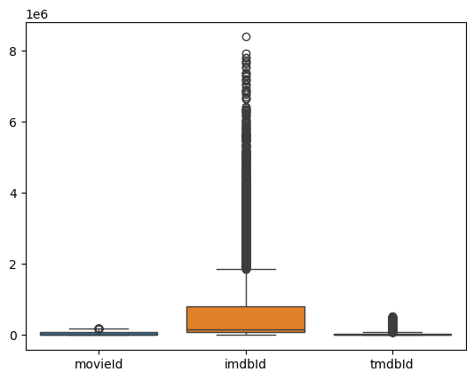

```python
#check for outliers
sns.boxplot(links_df);
```

**Observation**

The links dataset seems to have many outliers in the `imdbId` column but they are genuine outliers; so we will keep them.

## 2. Movies Dataset

```python
#load and read dataset
movies_df = pd.read_csv("Data/movies.csv")
movies_df
```

|  | movieId | title | genres |
| --- | --- | --- | --- |
| 0 | 1 | Toy Story (1995) | Adventure\|Animation\|Children\|Comedy\|Fantasy |
| 1 | 2 | Jumanji (1995) | Adventure\|Children\|Fantasy |
| 2 | 3 | Grumpier Old Men (1995) | Comedy\|Romance |
| 3 | 4 | Waiting to Exhale (1995) | Comedy\|Drama\|Romance |
| 4 | 5 | Father of the Bride Part II (1995) | Comedy |
| ... | ... | ... | ... |
| 9737 | 193581 | Black Butler: Book of the Atlantic (2017) | Action\|Animation\|Comedy\|Fantasy |
| 9738 | 193583 | No Game No Life: Zero (2017) | Animation\|Comedy\|Fantasy |
| 9739 | 193585 | Flint (2017) | Drama |
| 9740 | 193587 | Bungo Stray Dogs: Dead Apple (2018) | Action\|Animation |
| 9741 | 193609 | Andrew Dice Clay: Dice Rules (1991) | Comedy |

9742 rows × 3 columns

### Dataset Description

```python
#check the first 5 rows
movies_df.head()
```

|  | movieId | title | genres |
| --- | --- | --- | --- |
| 0 | 1 | Toy Story (1995) | Adventure\|Animation\|Children\|Comedy\|Fantasy |
| 1 | 2 | Jumanji (1995) | Adventure\|Children\|Fantasy |
| 2 | 3 | Grumpier Old Men (1995) | Comedy\|Romance |
| 3 | 4 | Waiting to Exhale (1995) | Comedy\|Drama\|Romance |
| 4 | 5 | Father of the Bride Part II (1995) | Comedy |

```python
#check the last 5 rows
movies_df.tail()
```

|  | movieId | title | genres |
| --- | --- | --- | --- |
| 9737 | 193581 | Black Butler: Book of the Atlantic (2017) | Action\|Animation\|Comedy\|Fantasy |
| 9738 | 193583 | No Game No Life: Zero (2017) | Animation\|Comedy\|Fantasy |
| 9739 | 193585 | Flint (2017) | Drama |
| 9740 | 193587 | Bungo Stray Dogs: Dead Apple (2018) | Action\|Animation |
| 9741 | 193609 | Andrew Dice Clay: Dice Rules (1991) | Comedy |

**Observation**

The movies dataset is uniform from start to finish.

```python
#get metadata
movies_df.info()
```

```
<class 'pandas.core.frame.DataFrame'>
RangeIndex: 9742 entries, 0 to 9741
Data columns (total 3 columns):
 #   Column   Non-Null Count  Dtype
---  ------   --------------  -----
 0   movieId  9742 non-null   int64
 1   title    9742 non-null   object
 2   genres   9742 non-null   object
dtypes: int64(1), object(2)
memory usage: 228.5+ KB
```

**Observation**

The movies dataset has one numerical column and 2 categorical columns.

```python
#check shape
print(f"The movies dataset has {movies_df.shape[0]} rows and {movies_df.shape[1]} columns.")
```

```
The movies dataset has 9742 rows and 3 columns.
```

```python
#statistical summary of the numerical column
movies_df.describe().T
```

|  | count | mean | std | min | 25% | 50% | 75% | max |
| --- | --- | --- | --- | --- | --- | --- | --- | --- |
| movieId | 9742.0 | 42200.353623 | 52160.494854 | 1.0 | 3248.25 | 7300.0 | 76232.0 | 193609.0 |

```python
#statistical summary of the categorical columns
movies_df.describe(include="object").T
```

|  | count | unique | top | freq |
| --- | --- | --- | --- | --- |
| title | 9742 | 9737 | Emma (1996) | 2 |
| genres | 9742 | 951 | Drama | 1053 |

```python
#check nulls
print(f" The movies dataset has {movies_df.isna().sum().sum()} null values.")
```

```
 The movies dataset has 0 null values.
```

```python
#check duplicates
print(f"The movies dataset has {movies_df.duplicated().sum()} duplicates.")
```

```
The movies dataset has 0 duplicates.
```

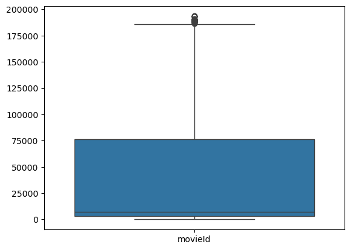

```python
#check for outliers
sns.boxplot(movies_df);
```

**Observation**

## 3. Ratings Dataset

```python
#load and read dataset
ratings_df = pd.read_csv("Data/ratings.csv")
ratings_df
```

|  | userId | movieId | rating | timestamp |
| --- | --- | --- | --- | --- |
| 0 | 1 | 1 | 4.0 | 964982703 |
| 1 | 1 | 3 | 4.0 | 964981247 |
| 2 | 1 | 6 | 4.0 | 964982224 |
| 3 | 1 | 47 | 5.0 | 964983815 |
| 4 | 1 | 50 | 5.0 | 964982931 |
| ... | ... | ... | ... | ... |
| 100831 | 610 | 166534 | 4.0 | 1493848402 |
| 100832 | 610 | 168248 | 5.0 | 1493850091 |
| 100833 | 610 | 168250 | 5.0 | 1494273047 |
| 100834 | 610 | 168252 | 5.0 | 1493846352 |
| 100835 | 610 | 170875 | 3.0 | 1493846415 |

100836 rows × 4 columns

### Dataset Description

- Each row represents one rating of one movie by one user.
- `rating` are made on a 5-star scale with half-star increments (0.5 stars - 5.0 stars).
- `timestamp` represents seconds since midnight Coordinated Universal Time (UTC) of January 1, 1970.

```python
#check the first 5 rows
ratings_df.head()
```

|  | userId | movieId | rating | timestamp |
| --- | --- | --- | --- | --- |
| 0 | 1 | 1 | 4.0 | 964982703 |
| 1 | 1 | 3 | 4.0 | 964981247 |
| 2 | 1 | 6 | 4.0 | 964982224 |
| 3 | 1 | 47 | 5.0 | 964983815 |
| 4 | 1 | 50 | 5.0 | 964982931 |

```python
#check the last rows
ratings_df.tail()
```

|  | userId | movieId | rating | timestamp |
| --- | --- | --- | --- | --- |
| 100831 | 610 | 166534 | 4.0 | 1493848402 |
| 100832 | 610 | 168248 | 5.0 | 1493850091 |
| 100833 | 610 | 168250 | 5.0 | 1494273047 |
| 100834 | 610 | 168252 | 5.0 | 1493846352 |
| 100835 | 610 | 170875 | 3.0 | 1493846415 |

**Observation**

The ratings dataset is uniform from start to finish.

```python
#check shape
print(f"The ratings dataset has {ratings_df.shape[0]} rows and {ratings_df.shape[1]} columns.")
```

```
The ratings dataset has 100836 rows and 4 columns.
```

```python
#get metadata

ratings_df.info()
```

```
<class 'pandas.core.frame.DataFrame'>
RangeIndex: 100836 entries, 0 to 100835
Data columns (total 4 columns):
 #   Column     Non-Null Count   Dtype
---  ------     --------------   -----
 0   userId     100836 non-null  int64
 1   movieId    100836 non-null  int64
 2   rating     100836 non-null  float64
 3   timestamp  100836 non-null  int64
dtypes: float64(1), int64(3)
memory usage: 3.1 MB
```

**Observation**

The dataset has 4 numerical columns.

```python
#statistical summary of the numerical columns
ratings_df.describe().T
```

|  | count | mean | std | min | 25% | 50% | 75% | max |
| --- | --- | --- | --- | --- | --- | --- | --- | --- |
| userId | 100836.0 | 3.261276e+02 | 1.826185e+02 | 1.0 | 1.770000e+02 | 3.250000e+02 | 4.770000e+02 | 6.100000e+02 |
| movieId | 100836.0 | 1.943530e+04 | 3.553099e+04 | 1.0 | 1.199000e+03 | 2.991000e+03 | 8.122000e+03 | 1.936090e+05 |
| rating | 100836.0 | 3.501557e+00 | 1.042529e+00 | 0.5 | 3.000000e+00 | 3.500000e+00 | 4.000000e+00 | 5.000000e+00 |
| timestamp | 100836.0 | 1.205946e+09 | 2.162610e+08 | 828124615.0 | 1.019124e+09 | 1.186087e+09 | 1.435994e+09 | 1.537799e+09 |

```python
#check nulls
print(f"The ratings dataset has {ratings_df.isna().sum().sum()} null values.")
```

```
The ratings dataset has 0 null values.
```

```python
#check duplicates
print(f"The ratings dataset has {ratings_df.duplicated().sum()} duplicates.")
```

```
The ratings dataset has 0 duplicates.
```

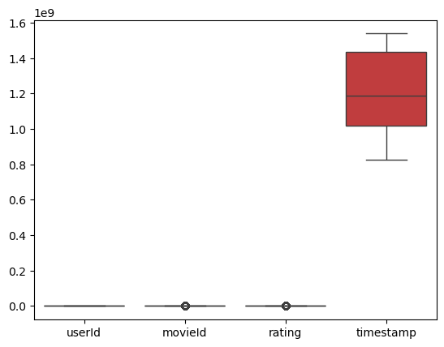

```python
#check for outliers
sns.boxplot(ratings_df);
```

**Observation**

## 4. Tags Dataset

```python
#load and read dataset
tags_df = pd.read_csv("Data/tags.csv")
tags_df
```

|  | userId | movieId | tag | timestamp |
| --- | --- | --- | --- | --- |
| 0 | 2 | 60756 | funny | 1445714994 |
| 1 | 2 | 60756 | Highly quotable | 1445714996 |
| 2 | 2 | 60756 | will ferrell | 1445714992 |
| 3 | 2 | 89774 | Boxing story | 1445715207 |
| 4 | 2 | 89774 | MMA | 1445715200 |
| ... | ... | ... | ... | ... |
| 3678 | 606 | 7382 | for katie | 1171234019 |
| 3679 | 606 | 7936 | austere | 1173392334 |
| 3680 | 610 | 3265 | gun fu | 1493843984 |
| 3681 | 610 | 3265 | heroic bloodshed | 1493843978 |
| 3682 | 610 | 168248 | Heroic Bloodshed | 1493844270 |

3683 rows × 4 columns

### Dataset Description

- Tags are user-generated metadata about movies. Each `tag` is typically a single word or short phrase. The meaning, value and purpose of a particular tag is determined by each user.
- `timestamp` represent seconds since midnight Coordinated Universal Time (UTC) of January 1, 1970

```python
#check the first 5 rows
tags_df.head()
```

|  | userId | movieId | tag | timestamp |
| --- | --- | --- | --- | --- |
| 0 | 2 | 60756 | funny | 1445714994 |
| 1 | 2 | 60756 | Highly quotable | 1445714996 |
| 2 | 2 | 60756 | will ferrell | 1445714992 |
| 3 | 2 | 89774 | Boxing story | 1445715207 |
| 4 | 2 | 89774 | MMA | 1445715200 |

```python
#check the last 5 rows
tags_df.tail()
```

|  | userId | movieId | tag | timestamp |
| --- | --- | --- | --- | --- |
| 3678 | 606 | 7382 | for katie | 1171234019 |
| 3679 | 606 | 7936 | austere | 1173392334 |
| 3680 | 610 | 3265 | gun fu | 1493843984 |
| 3681 | 610 | 3265 | heroic bloodshed | 1493843978 |
| 3682 | 610 | 168248 | Heroic Bloodshed | 1493844270 |

**Observation**

The tags dataset is uniform from start to finish.

```python
#check shape
print(f"The tags dataset has {tags_df.shape[0]} rows and {tags_df.shape[1]} columns.")
```

```
The tags dataset has 3683 rows and 4 columns.
```

```python
#get metadata
tags_df.info()
```

```
<class 'pandas.core.frame.DataFrame'>
RangeIndex: 3683 entries, 0 to 3682
Data columns (total 4 columns):
 #   Column     Non-Null Count  Dtype
---  ------     --------------  -----
 0   userId     3683 non-null   int64
 1   movieId    3683 non-null   int64
 2   tag        3683 non-null   object
 3   timestamp  3683 non-null   int64
dtypes: int64(3), object(1)
memory usage: 115.2+ KB
```

**Observation**

The tags dataset has one categorical columns and 3 numerical columns.

```python
#statistical summary of numerical columns
tags_df.describe().T
```

|  | count | mean | std | min | 25% | 50% | 75% | max |
| --- | --- | --- | --- | --- | --- | --- | --- | --- |
| userId | 3683.0 | 4.311493e+02 | 1.584726e+02 | 2.000000e+00 | 4.240000e+02 | 4.740000e+02 | 4.770000e+02 | 6.100000e+02 |
| movieId | 3683.0 | 2.725201e+04 | 4.349056e+04 | 1.000000e+00 | 1.262500e+03 | 4.454000e+03 | 3.926300e+04 | 1.935650e+05 |
| timestamp | 3683.0 | 1.320032e+09 | 1.721025e+08 | 1.137179e+09 | 1.137521e+09 | 1.269833e+09 | 1.498457e+09 | 1.537099e+09 |

```python
#statistical summary of the categorical column
tags_df.describe(include="object").T
```

|  | count | unique | top | freq |
| --- | --- | --- | --- | --- |
| tag | 3683 | 1589 | In Netflix queue | 131 |

```python
#check for nulls
print(f"The tags dataset has {tags_df.isna().sum().sum()} null values.")
```

```
The tags dataset has 0 null values.
```

```python
#check for duplicates
print(f"The tags dataset has {tags_df.duplicated().sum()} duplicates.")
```

```
The tags dataset has 0 duplicates.
```

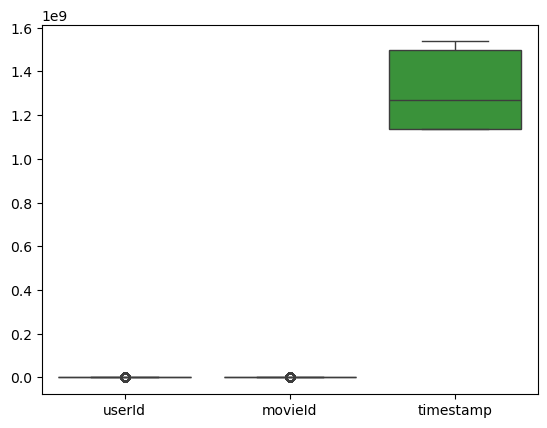

```python
#check for outliers
sns.boxplot(tags_df);
```

**Observation**

# Data Preparation

## Data Cleaning

```python
# Merging the datasets to have one large dataset
links_movies = pd.merge(links_df, movies_df, how="left", on="movieId")
final_df = pd.merge(ratings_df, links_movies, how = "left", on = "movieId")
final_df
```

|  | userId | movieId | rating | timestamp | imdbId | tmdbId | title | genres |
| --- | --- | --- | --- | --- | --- | --- | --- | --- |
| 0 | 1 | 1 | 4.0 | 964982703 | 114709 | 862.0 | Toy Story (1995) | Adventure\|Animation\|Children\|Comedy\|Fantasy |
| 1 | 1 | 3 | 4.0 | 964981247 | 113228 | 15602.0 | Grumpier Old Men (1995) | Comedy\|Romance |
| 2 | 1 | 6 | 4.0 | 964982224 | 113277 | 949.0 | Heat (1995) | Action\|Crime\|Thriller |
| 3 | 1 | 47 | 5.0 | 964983815 | 114369 | 807.0 | Seven (a.k.a. Se7en) (1995) | Mystery\|Thriller |
| 4 | 1 | 50 | 5.0 | 964982931 | 114814 | 629.0 | Usual Suspects, The (1995) | Crime\|Mystery\|Thriller |
| ... | ... | ... | ... | ... | ... | ... | ... | ... |
| 100831 | 610 | 166534 | 4.0 | 1493848402 | 4972582 | 381288.0 | Split (2017) | Drama\|Horror\|Thriller |
| 100832 | 610 | 168248 | 5.0 | 1493850091 | 4425200 | 324552.0 | John Wick: Chapter Two (2017) | Action\|Crime\|Thriller |
| 100833 | 610 | 168250 | 5.0 | 1494273047 | 5052448 | 419430.0 | Get Out (2017) | Horror |
| 100834 | 610 | 168252 | 5.0 | 1493846352 | 3315342 | 263115.0 | Logan (2017) | Action\|Sci-Fi |
| 100835 | 610 | 170875 | 3.0 | 1493846415 | 4630562 | 337339.0 | The Fate of the Furious (2017) | Action\|Crime\|Drama\|Thriller |

100836 rows × 8 columns

*Note:* The `tags_df` dataset was not included in the merging as its content will input around 97% of null values in our dataset which would not be ideal.

```python
# Dropping unnecessary columns
final_df = final_df.drop(columns = ["timestamp", "imdbId", "tmdbId"], axis = 1)
final_df
```

|  | userId | movieId | rating | title | genres |
| --- | --- | --- | --- | --- | --- |
| 0 | 1 | 1 | 4.0 | Toy Story (1995) | Adventure\|Animation\|Children\|Comedy\|Fantasy |
| 1 | 1 | 3 | 4.0 | Grumpier Old Men (1995) | Comedy\|Romance |
| 2 | 1 | 6 | 4.0 | Heat (1995) | Action\|Crime\|Thriller |
| 3 | 1 | 47 | 5.0 | Seven (a.k.a. Se7en) (1995) | Mystery\|Thriller |
| 4 | 1 | 50 | 5.0 | Usual Suspects, The (1995) | Crime\|Mystery\|Thriller |
| ... | ... | ... | ... | ... | ... |
| 100831 | 610 | 166534 | 4.0 | Split (2017) | Drama\|Horror\|Thriller |
| 100832 | 610 | 168248 | 5.0 | John Wick: Chapter Two (2017) | Action\|Crime\|Thriller |
| 100833 | 610 | 168250 | 5.0 | Get Out (2017) | Horror |
| 100834 | 610 | 168252 | 5.0 | Logan (2017) | Action\|Sci-Fi |
| 100835 | 610 | 170875 | 3.0 | The Fate of the Furious (2017) | Action\|Crime\|Drama\|Thriller |

100836 rows × 5 columns

**Observation**

The `timestamp`, `imdbId`, `tmdbId` columns were dropped as they were seen as redundant. They are doing the same task as `movieId` as they are all seen as identifiers.

```python
# Extracting the year from title
final_df["year"] = final_df["title"].str.extract(r'\((\d{4})\)')

# Removing the year from title column
final_df['title'] = final_df['title'].str.replace(r'\s*\(\d{4,}\)', '', regex=True).str.strip()

# Checking if creating the new column created null values
final_df.isna().sum()
```

```
userId      0
movieId     0
rating      0
title       0
genres      0
year       18
dtype: int64
```

```python
# Viewing which rows have not been assigned a year
final_df[final_df["year"].isna()]
```

|  | userId | movieId | rating | title | genres | year |
| --- | --- | --- | --- | --- | --- | --- |
| 9147 | 62 | 176601 | 5.0 | Black Mirror | (no genres listed) | NaN |
| 16886 | 105 | 147250 | 5.0 | The Adventures of Sherlock Holmes and Doctor W... | (no genres listed) | NaN |
| 16913 | 105 | 171749 | 5.0 | Death Note: Desu nôto (2006–2007) | (no genres listed) | NaN |
| 17879 | 111 | 171631 | 1.0 | Maria Bamford: Old Baby | (no genres listed) | NaN |
| 17881 | 111 | 171891 | 3.5 | Generation Iron 2 | (no genres listed) | NaN |
| 30039 | 209 | 140956 | 3.5 | Ready Player One | Action\|Sci-Fi\|Thriller | NaN |
| 30090 | 210 | 40697 | 4.0 | Babylon 5 | Sci-Fi | NaN |
| 46593 | 305 | 140956 | 4.5 | Ready Player One | Action\|Sci-Fi\|Thriller | NaN |
| 46711 | 306 | 149334 | 3.0 | Nocturnal Animals | Drama\|Thriller | NaN |
| 49851 | 318 | 171495 | 5.0 | Cosmos | (no genres listed) | NaN |
| 58040 | 380 | 140956 | 3.0 | Ready Player One | Action\|Sci-Fi\|Thriller | NaN |
| 64964 | 414 | 167570 | 4.0 | The OA | (no genres listed) | NaN |
| 70432 | 448 | 143410 | 2.0 | Hyena Road | (no genres listed) | NaN |
| 71984 | 462 | 162414 | 5.0 | Moonlight | Drama | NaN |
| 81445 | 514 | 140956 | 3.0 | Ready Player One | Action\|Sci-Fi\|Thriller | NaN |
| 83380 | 528 | 40697 | 0.5 | Babylon 5 | Sci-Fi | NaN |
| 88136 | 567 | 156605 | 4.5 | Paterson | (no genres listed) | NaN |
| 95078 | 599 | 171495 | 4.0 | Cosmos | (no genres listed) | NaN |

```python
# Imputing the correct years to the missing rows using research
final_df.loc[final_df["title"] == "Black Mirror", "year"] = "2011"
final_df.loc[final_df["title"] == "The Adventures of Sherlock Holmes and Doctor Watson", "year"] = "1980"
final_df.loc[final_df["title"] == "Death Note: Desu nôto (2006–2007)", "year"] = "2006"
final_df.loc[final_df["title"] == "Maria Bamford: Old Baby", "year"] = "2017"
final_df.loc[final_df["title"] == "Generation Iron 2", "year"] = "2017"
final_df.loc[final_df["title"] == "Ready Player One", "year"] = "2018"
final_df.loc[final_df["title"] == "Nocturnal Animals", "year"] = "2016"
final_df.loc[final_df["title"] == "Cosmos", "year"] = "2019"
final_df.loc[final_df["title"] == "The OA", "year"] = "2016"
final_df.loc[final_df["title"] == "Hyena Road", "year"] = "2015"
final_df.loc[final_df["title"] == "Moonlight", "year"] = "2016"
final_df.loc[final_df["title"] == "Paterson", "year"] = "2016"
final_df.loc[final_df["title"] == "Babylon 5", "year"] = "1994"

# Converting the year into an integer
final_df["year"] = final_df["year"].astype("int64")

# Confirming
final_df.info()
```

```
<class 'pandas.core.frame.DataFrame'>
RangeIndex: 100836 entries, 0 to 100835
Data columns (total 6 columns):
 #   Column   Non-Null Count   Dtype
---  ------   --------------   -----
 0   userId   100836 non-null  int64
 1   movieId  100836 non-null  int64
 2   rating   100836 non-null  float64
 3   title    100836 non-null  object
 4   genres   100836 non-null  object
 5   year     100836 non-null  int64
dtypes: float64(1), int64(3), object(2)
memory usage: 4.6+ MB
```

```python
# Confirming that there are no null values
final_df.isna().sum()
```

```
userId     0
movieId    0
rating     0
title      0
genres     0
year       0
dtype: int64
```

```python
print(f"Our final_df dataset contains {final_df.duplicated().sum()} duplicated values and {final_df.isna().sum().sum()} null values.")
```

```
Our final_df dataset contains 0 duplicated values and 0 null values.
```

```python
# Rearranging the columns
col_order = ["userId", "movieId", "title", "year", "genres", "rating"]
final_df = final_df[col_order].reset_index(drop = True)

# Confirming changes
final_df
```

|  | userId | movieId | title | year | genres | rating |
| --- | --- | --- | --- | --- | --- | --- |
| 0 | 1 | 1 | Toy Story | 1995 | Adventure\|Animation\|Children\|Comedy\|Fantasy | 4.0 |
| 1 | 1 | 3 | Grumpier Old Men | 1995 | Comedy\|Romance | 4.0 |
| 2 | 1 | 6 | Heat | 1995 | Action\|Crime\|Thriller | 4.0 |
| 3 | 1 | 47 | Seven (a.k.a. Se7en) | 1995 | Mystery\|Thriller | 5.0 |
| 4 | 1 | 50 | Usual Suspects, The | 1995 | Crime\|Mystery\|Thriller | 5.0 |
| ... | ... | ... | ... | ... | ... | ... |
| 100831 | 610 | 166534 | Split | 2017 | Drama\|Horror\|Thriller | 4.0 |
| 100832 | 610 | 168248 | John Wick: Chapter Two | 2017 | Action\|Crime\|Thriller | 5.0 |
| 100833 | 610 | 168250 | Get Out | 2017 | Horror | 5.0 |
| 100834 | 610 | 168252 | Logan | 2017 | Action\|Sci-Fi | 5.0 |
| 100835 | 610 | 170875 | The Fate of the Furious | 2017 | Action\|Crime\|Drama\|Thriller | 3.0 |

100836 rows × 6 columns

Our dataset is now clean and ready for Exploratory Data Analysis and Modeling

```python
# Saving the file
final_df.to_csv("Data/Merged_data.csv", index = False)
```

# Exploratory Data Analysis

## Univariate analysis

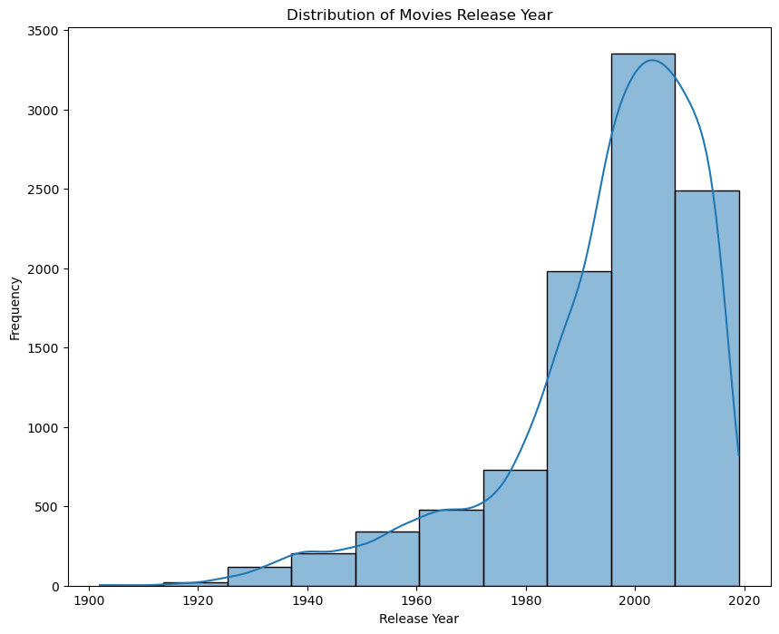

```python
#distribution of the year movies were released
final_df_copy = final_df.drop_duplicates(subset="movieId")
plt.figure(figsize=(10,8))
sns.histplot(final_df_copy['year'], kde= True, bins=10)
plt.title("Distribution of Movies Release Year")
plt.xlabel("Release Year")
plt.ylabel("Frequency")
plt.show()
```

**Observation**

- Most of the movies in our dataset were released after the 80s.This makes it to be negatively skewed.
- The oldest movies in our dataset were released around the 1900s.

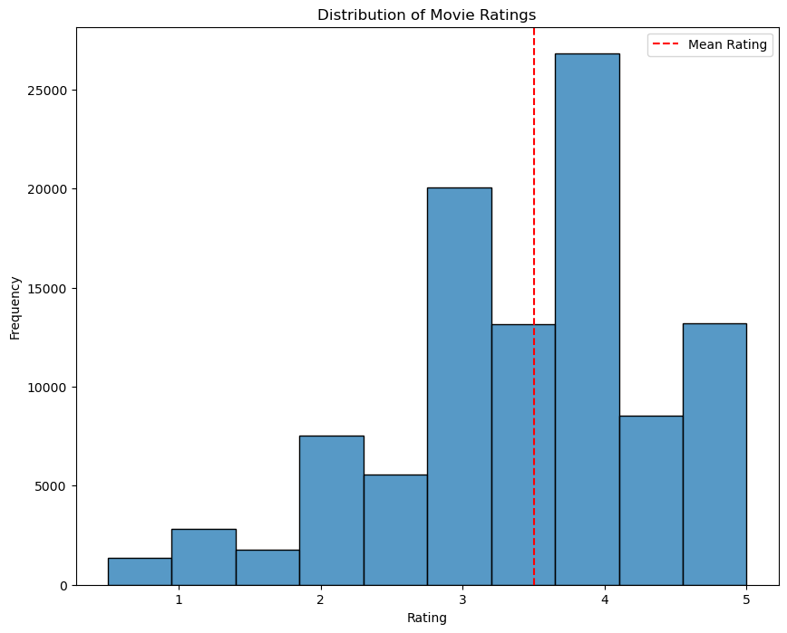

```python
# distribution of ratings
plt.figure(figsize=(10,8))
sns.histplot(final_df['rating'], bins=10)
plt.title("Distribution of Movie Ratings")
plt.xlabel("Rating")
plt.axvline(x=final_df['rating'].mean(),color='red', linestyle='--', label= 'Mean Rating')
plt.ylabel("Frequency")
plt.legend()
plt.show()
```

**Observation**

- Over 25000 movies have been given a rating of 4.
- Less than 5000 movies have been given a rating of less than 1.5
- The mean rating of our dataset is around 3.5

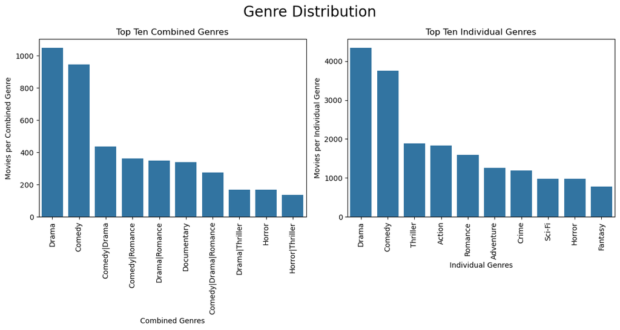

```python
#making a copy of the dataset to separate the genres individually
exploded_df = final_df_copy.copy(deep=True)
exploded_df['genres'] = exploded_df['genres'].str.split("|")
exploded_df = exploded_df.explode('genres')
exploded_df

fig, axis= plt.subplots(ncols=2, figsize=(12,6))

#visualizing the combined genres
sns.countplot(data=final_df_copy, x='genres', order= final_df_copy['genres'].value_counts().head(10).index,ax=axis[0])
axis[0].set_title("Top Ten Combined Genres")
axis[0].set_ylabel('Movies per Combined Genre')
axis[0].set_xlabel('Combined Genres')
axis[0].tick_params(axis='x', rotation=90)

#visualizing the individual genres
sns.barplot(data= exploded_df['genres'].value_counts().head(10),ax=axis[1])
axis[1].set_title("Top Ten Individual Genres")
axis[1].set_ylabel('Movies per Individual Genre')
axis[1].set_xlabel('Individual Genres')
axis[1].tick_params(axis='x', rotation=90)

plt.tight_layout()
plt.suptitle("Genre Distribution", fontsize=20, y= 1.05)
plt.show()
```

**Observation**

- Drama and comedy are the most dominant genres individually and also when combined with other genres.
- Drama is also the most present genre in the other combinations followed by comedy.
- A combination of comedy and drama genres are third highest in the combined genres plot.

## Bivariate Analysis

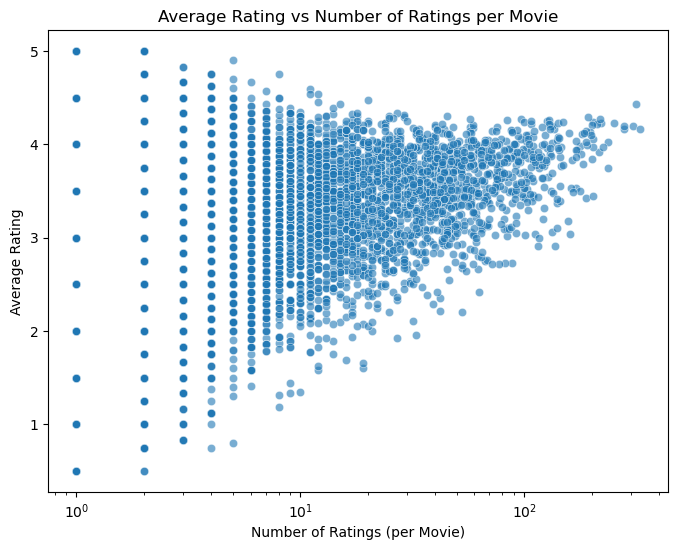

```python
# Calculate average rating and number of ratings per movie
movie_stats = final_df.groupby('movieId').agg(
    avg_rating=('rating', 'mean'),
    num_ratings=('rating', 'count')
).reset_index()

# Plot
plt.figure(figsize=(8,6))
sns.scatterplot(data=movie_stats, x='num_ratings', y='avg_rating', alpha=0.6)
plt.title('Average Rating vs Number of Ratings per Movie')
plt.xlabel('Number of Ratings (per Movie)')
plt.ylabel('Average Rating')
plt.xscale('log')
plt.show()
```

**Observation**

- Movies with fewer ratings tend to have extreme averages

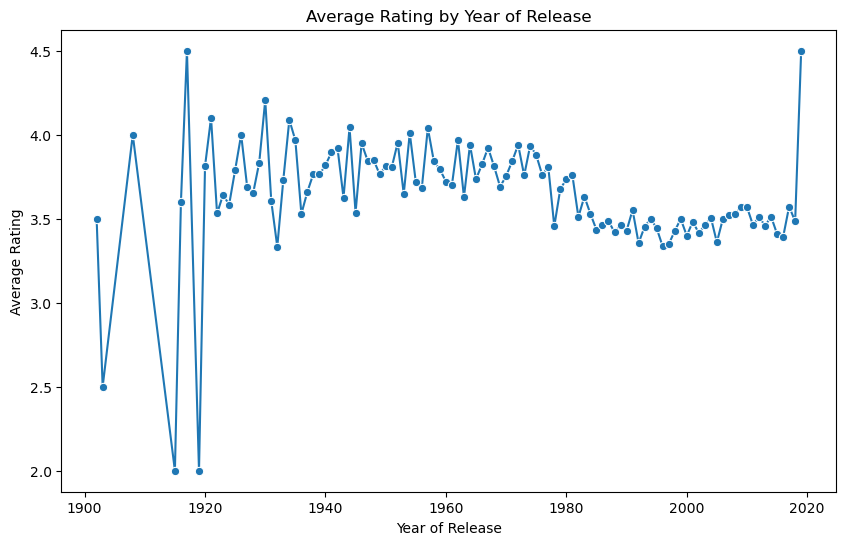

```python
# Compute mean rating per year
yearly_ratings = final_df.groupby('year')['rating'].mean().reset_index()

# Plot
plt.figure(figsize=(10,6))
sns.lineplot(data=yearly_ratings, x='year', y='rating', marker='o')
plt.title('Average Rating by Year of Release')
plt.xlabel('Year of Release')
plt.ylabel('Average Rating')
plt.show()
```

**Observation**

- Older movies have a higher rating compared to newer movies whichhave an average rating

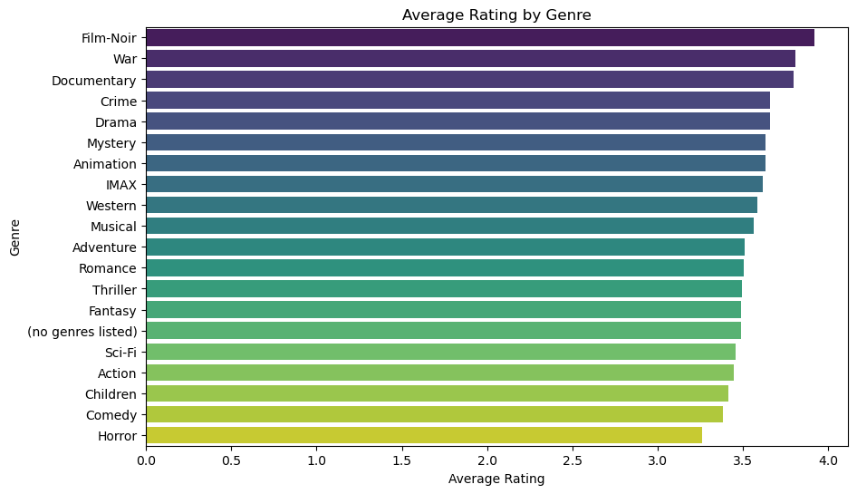

```python
# Split multiple genres into separate rows
genres_exploded = final_df.assign(genre=final_df['genres'].str.split('|')).explode('genre')

# Calculate average rating per genre
genre_ratings = genres_exploded.groupby('genre')['rating'].mean().sort_values(ascending=False).reset_index()

# Bar chart
plt.figure(figsize=(10,6))
sns.barplot(data=genre_ratings, x='rating', y='genre', palette='viridis')
plt.title('Average Rating by Genre')
plt.xlabel('Average Rating')
plt.ylabel('Genre')
plt.show()
```

**Observation**

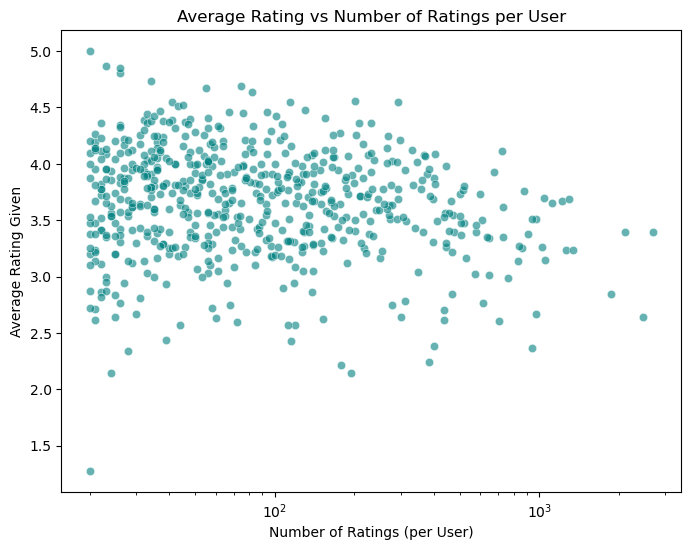

```python
# Compute user statistics
user_stats = final_df.groupby('userId').agg(
    avg_rating=('rating', 'mean'),
    num_ratings=('rating', 'count')
).reset_index()

# Plot
plt.figure(figsize=(8,6))
sns.scatterplot(data=user_stats, x='num_ratings', y='avg_rating', alpha=0.6, color='teal')
plt.title('Average Rating vs Number of Ratings per User')
plt.xlabel('Number of Ratings (per User)')
plt.ylabel('Average Rating Given')
plt.xscale('log')
plt.show()
```

**Observation**

- Users who rate fewer movies often give higher ratings compared to users who rate more movies tend tohave lower more balanced ratings

## Multivariate Analysis

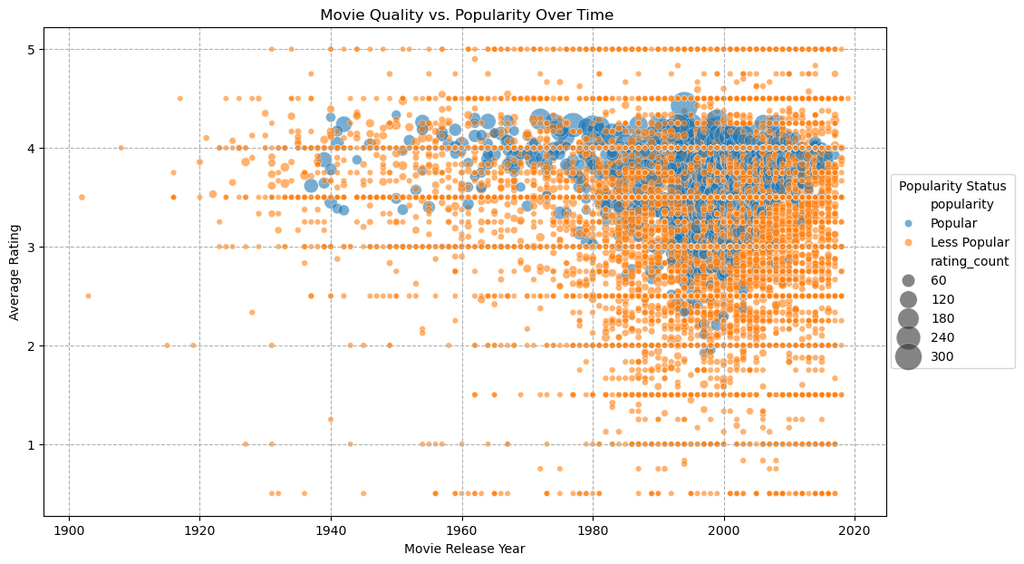

```python
# Exploding the genres
expanded_genres = final_df['genres'].str.split('|').explode()

#create a copy to use for aggregation
df_agg = final_df.copy()

# Group by MovieId to get volume, quality, and year
movie_stats = df_agg.groupby('movieId').agg(
    avg_rating=('rating', 'mean'),
    rating_count=('rating', 'count'),
    year=('year', 'first')
).reset_index()

# Classify Movies by Popularity (Rating Count)
# Define popularity bins
popularity_threshold = movie_stats['rating_count'].quantile(0.90)
movie_stats['popularity'] = ['Popular' if count >= popularity_threshold else 'Less Popular'
                             for count in movie_stats['rating_count']]

# plot
plt.figure(figsize=(12, 7))
sns.scatterplot(
    x='year',
    y='avg_rating',
    size='rating_count',
    hue='popularity',
    data=movie_stats,
    alpha=0.6,
    sizes=(20, 500)
)
plt.title(' Movie Quality vs. Popularity Over Time')
plt.xlabel('Movie Release Year')
plt.ylabel('Average Rating')
plt.legend(title='Popularity Status', loc='center right', bbox_to_anchor =[1, 0, 0.16, 1])
plt.grid(True, linestyle='--')
plt.show();
```

**Observation**

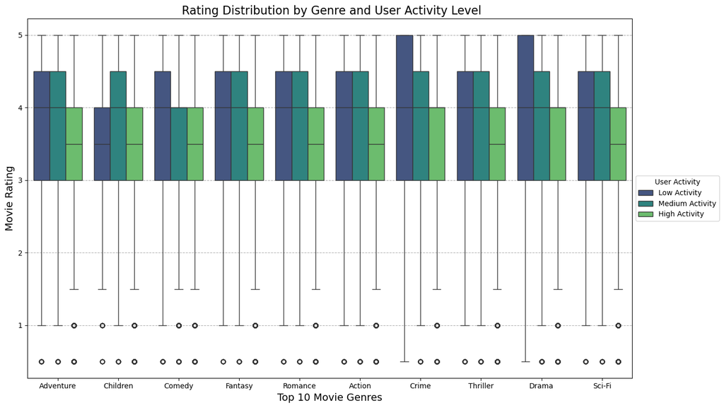

```python
#Classify Movies by Popularity (Rating Count)
# Define popularity bins
popularity_threshold = movie_stats['rating_count'].quantile(0.90)
movie_stats['popularity'] = ['Popular' if count >= popularity_threshold else 'Less Popular'
                             for count in movie_stats['rating_count']]

# Re-run the genre expansion step
df_expanded = final_df.assign(genres=final_df['genres'].str.split('|')).explode('genres')
df_expanded = df_expanded[df_expanded['genres'] != '(no genres listed)']


# Calculate total ratings per user
user_counts = df_expanded['userId'].value_counts()
# Create bins for activity levels
bins = user_counts.quantile([0, 0.33, 0.66, 1.0]).tolist()
labels = ['Low Activity', 'Medium Activity', 'High Activity']

# Map the activity level back to the main DataFrame
df_expanded['user_activity'] = df_expanded['userId'].map(
    pd.cut(user_counts, bins=bins, labels=labels, include_lowest=True, duplicates='drop')
)


# Identify the top 10 most common genres for focused visualization
top_genres = df_expanded['genres'].value_counts().nlargest(10).index.tolist()
df_top_genres = df_expanded[df_expanded['genres'].isin(top_genres)]

# plot

plt.figure(figsize=(14, 8))
sns.boxplot(
    x='genres',
    y='rating',
    hue='user_activity',
    data=df_top_genres,
    palette='viridis'
)

plt.title(' Rating Distribution by Genre and User Activity Level', fontsize=16)
plt.xlabel('Top 10 Movie Genres', fontsize=14)
plt.ylabel('Movie Rating', fontsize=14)
plt.legend(title='User Activity', loc='center right', bbox_to_anchor =[1, 0, 0.15, 1])
plt.grid(axis='y', linestyle='--')
plt.tight_layout()
plt.show();
```

**Observation**